# k-Nearest Neighbor classification and regression

Evan Muzzall

2/3/2017

# 0. Package installation

Today we will use the following packages. Although we won’t use it today, we recommend installing “SuperLearner” as well.

```r
install.packages(c("caret", "chemometrics", "class", "FNN", "gmodels", "ggplot2", "MASS", "SuperLearner"), dependencies=TRUE)
library(caret)
library(chemometrics)
library(class)
library(FNN)
library(gmodels)
library(ggplot2)
library(MASS)
library(SuperLearner)
```

# 1. What is k-Nearest Neighbors? (kNN)

kNN is a form of “lazy” learning in which data are categorized based on similarities with their “nearest” neighbors. kNN can be thought of as non-parametric instance-based learning. Compared to other algorithms, KNN is simple and makes no assumptions about the underlying data structure.

The data are treated as coordinates in a multidimensional feature space to organize the desired groups that are identified. kNN is distance-based and distills variation contained within multiple variables into a reduced number of principal axes.

Euclidean (straight-line Cartesian) distance is one standard for KNN and the distance we will use today. However, many consider Mahalanobis distance a more appropriate multivariate distance for kNN and other statistical tests. See for example:

[Weinberger et al. 2009. Distance Metric Learning for Large Margin Nearest Neighbor Classification. Journal of Machine Learning Reseach 10: 207-244](http://jmlr.csail.mit.edu/papers/volume10/weinberger09a/weinberger09a.pdf)

# 2. The data

Load the “Boston” housing dataset from the “MASS” R package and check it out:

```r
library(MASS)
data(Boston)
```

```r
head(Boston)
?Boston
str(Boston)
```

Today we will walk through classification and then regression using kNN. For classification, we want the response variable to be a factor. For regression, we want the response variable to remain numeric. Thus, we will first make a copy of the “Boston” dataset for the regression, before we arbitrarily convert it to a factor for classification:

```r
B_reg <- Boston
```

Time to get creative! Let’s do a little data wrangling and coerce the “dis” variable (weighted mean of distances to five Boston employment centers) into a factor category. The distances will now be categorized as “short”, “medium”, or “long”.

```r
summary(Boston$dis)
```

```
##    Min. 1st Qu.  Median    Mean 3rd Qu.    Max.
##   1.130   2.100   3.207   3.795   5.188  12.130
```

```r
Boston$dis <- cut(Boston$dis,
                  breaks=c(0, 3, 6, 13),
                  levels=c(1,2,3),
                  labels=c("short", "medium", "long"))
table(Boston$dis)
```

```
##
##  short medium   long
##    240    179     87
```

```r
str(Boston)
head(Boston, 10)
```

# 3. Choosing a proper k

The “k” in kNN represents the number of other “neighboring” data points used to classify the point in question. Consider the bias-variance tradeoff when choosing a proper “k”.

[Click here for Jason Brownlee’s excellent introduction to the bias-variance tradeoff](http://machinelearningmastery.com/gentle-introduction-to-the-bias-variance-trade-off-in-machine-learning/)

For example, **if we choose a large “k”,** it is easy for the majority class to win because it will always get the most votes and the “nearest neighbors” would not exert their proper influence. Or, **if we choose a tiny “k”,** noise and outliers could unduly influence the classification of the point being classified, again disregarding the influence of the other “nearest neighbors”.

```r
library(caret)
set.seed(1)
split <- createDataPartition(Boston$dis, p=0.70, list=FALSE)
train <- Boston[split, ]
test <- Boston[-split, ]

train_labels <- train[,8]
test_labels <- test[,8]
```

# 5. Train the model

Time to classify! Fit the model to the training data using the `knn` function from the “class” package. This outputs a vector of the predicted classifications. However, let’s first choose a “k” using the square root method:

```r
library(class)
?knn # (click the option from the "class" library)
```

```r
round(sqrt(nrow(train)),2) # 18.84
```

```
## [1] 18.84
```

```r
set.seed(1)
Boston_p <- knn(train=train[,-8], test=test[,-8], cl=train_labels, k=19, prob=TRUE)
```

### 5.1. Evaluate its performance

```r
library(gmodels)
CrossTable(x=test_labels, y=Boston_p,
           prop.chisq=FALSE,
           prop.r=FALSE,
           prop.c=FALSE,
           prop.t=FALSE)
```

```
##
##
##    Cell Contents
## |-------------------------|
## |                       N |
## |-------------------------|
##
##
## Total Observations in Table:  151
##
##
##              | Boston_p
##  test_labels |     short |    medium |      long | Row Total |
## -------------|-----------|-----------|-----------|-----------|
##        short |        64 |         8 |         0 |        72 |
## -------------|-----------|-----------|-----------|-----------|
##       medium |        10 |        38 |         5 |        53 |
## -------------|-----------|-----------|-----------|-----------|
##         long |         0 |        10 |        16 |        26 |
## -------------|-----------|-----------|-----------|-----------|
## Column Total |        74 |        56 |        21 |       151 |
## -------------|-----------|-----------|-----------|-----------|
##
##
```

- short: 64/72 correctly classified as short
- medium: 38/53 correctly classified as medium
- long: 16/26 correctly classified as long

> NOTE: remember that the breaks specified in the cut function above were arbitrary for this toy example.

### 5.2. Improve model performance

##### 1. Normalize the data

We don’t want larger values to indiscriminately affect results. Let’s standardize the data to a normal range so that their contributions to the decision-making process become roughly equal. We can do this with `scale`:

```r
?scale
```

Let’s name this scaled dataframe “B”:

```r
B <- Boston
B[,-8] <- scale(Boston[,-8], center=TRUE, scale=TRUE)
```

```r
head(B, 10)
```

Re-split the data using this transformed “B” dataframe:

```r
set.seed(1)
split_Z <- createDataPartition(B$dis, p=0.70, list=FALSE)
train_Z <- B[split_Z, ]
test_Z <- B[-split_Z, ]

train_labels_Z <- train_Z[,8]
test_labels_Z <- test_Z[,8]
```

Fit the model again:

```r
set.seed(1)
B_p <- knn(train=train_Z[,-8], test=test_Z[,-8], cl=train_labels_Z, k=19, prob=TRUE)

CrossTable(x=test_labels_Z, y=B_p,
           prop.chisq=FALSE,
           prop.r=FALSE,
           prop.c=FALSE,
           prop.t=FALSE)
```

```
##
##
##    Cell Contents
## |-------------------------|
## |                       N |
## |-------------------------|
##
##
## Total Observations in Table:  151
##
##
##               | B_p
## test_labels_Z |     short |    medium |      long | Row Total |
## --------------|-----------|-----------|-----------|-----------|
##         short |        58 |        14 |         0 |        72 |
## --------------|-----------|-----------|-----------|-----------|
##        medium |         6 |        39 |         8 |        53 |
## --------------|-----------|-----------|-----------|-----------|
##          long |         0 |         9 |        17 |        26 |
## --------------|-----------|-----------|-----------|-----------|
##  Column Total |        64 |        62 |        25 |       151 |
## --------------|-----------|-----------|-----------|-----------|
##
##
```

How did we do? - short: 58/72 correctly classified as short  
- medium: 39/53 correctly classified as medium  
- long: 17/26 correctly misclassified as long

##### 5.3. Change “k”

We can also change “k” to evaluate model performance. Ideally you would examine many a variety of kNN k-values and other algorithms simultaneously using the [“SuperLearner” R package](https://cran.r-project.org/web/packages/SuperLearner/index.html), but for today let’s just try a few extremes:

```r
B_p_k2 <- knn(train=train_Z[,-8], test=test_Z[,-8], cl=train_labels_Z, k=2, prob=TRUE)
B_p_k100 <- knn(train=train_Z[,-8], test=test_Z[,-8], cl=train_labels_Z, k=100, prob=TRUE)

CrossTable(x=test_labels_Z, y=B_p_k2,  # k=2
           prop.chisq=FALSE,
           prop.r=FALSE,
           prop.c=FALSE,
           prop.t=FALSE)
```

```
##
##
##    Cell Contents
## |-------------------------|
## |                       N |
## |-------------------------|
##
##
## Total Observations in Table:  151
##
##
##               | B_p_k2
## test_labels_Z |     short |    medium |      long | Row Total |
## --------------|-----------|-----------|-----------|-----------|
##         short |        67 |         3 |         2 |        72 |
## --------------|-----------|-----------|-----------|-----------|
##        medium |         4 |        42 |         7 |        53 |
## --------------|-----------|-----------|-----------|-----------|
##          long |         0 |         6 |        20 |        26 |
## --------------|-----------|-----------|-----------|-----------|
##  Column Total |        71 |        51 |        29 |       151 |
## --------------|-----------|-----------|-----------|-----------|
##
##
```

```r
CrossTable(x=test_labels_Z, y=B_p_k100,  # k=100
           prop.chisq=FALSE,
           prop.r=FALSE,
           prop.c=FALSE,
           prop.t=FALSE)
```

```
##
##
##    Cell Contents
## |-------------------------|
## |                       N |
## |-------------------------|
##
##
## Total Observations in Table:  151
##
##
##               | B_p_k100
## test_labels_Z |     short |    medium |      long | Row Total |
## --------------|-----------|-----------|-----------|-----------|
##         short |        52 |        20 |         0 |        72 |
## --------------|-----------|-----------|-----------|-----------|
##        medium |         6 |        45 |         2 |        53 |
## --------------|-----------|-----------|-----------|-----------|
##          long |         0 |        18 |         8 |        26 |
## --------------|-----------|-----------|-----------|-----------|
##  Column Total |        58 |        83 |        10 |       151 |
## --------------|-----------|-----------|-----------|-----------|
##
##
```

# 6. Another method with a CV error plotting function

Tidy the transformed “B” data a little:

```r
grp <- B$dis
X <- scale(B[-8], center=TRUE, scale=TRUE)
k <- length(unique(grp))
dat <- data.frame(grp, X)
n <- nrow(X)
n_train <- round(n*2/3)

set.seed(123)
train_plot=sample(1:n,n_train)
```

### 6.1 Plot the cross-validated errors

```r
library(chemometrics)
```

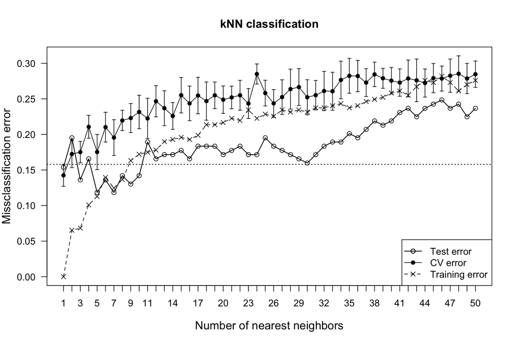

```r
#pdf("kNNplot.pdf", 9, 6)
knn_k <- knnEval(X, grp, train_plot, knnvec=seq(1,50, by=1), legpo="bottomright", las=2)
title("kNN classification")
```

```r
#dev.off()
```

# 7. Regression example

For the regression, let’s return to the B_reg copy that we made at the beginning because it preserved the numeric class of the “dis” variable.

First, scale the data that now contains the numeric response variable:

```r
B_reg <- as.data.frame(scale(B_reg, center=TRUE, scale=TRUE)) # transform the data
```

Second, split the data again:

```r
library(caret)
set.seed(1)
split_reg <- createDataPartition(B_reg$dis, p=0.70, list=FALSE) # split
train_reg <- B_reg[split,]
test_reg <- B_reg[-split,]
```

Third, fit the model and plot it!

```r
library(FNN)
```

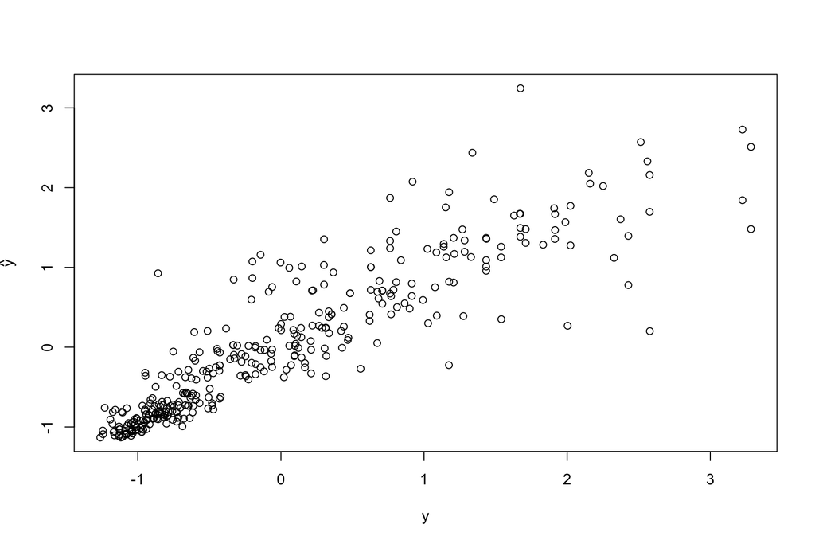

```r
set.seed(1)
knn_reg <- knn.reg(train_reg[,-8], test=NULL, y=train_reg[,8], k=3)
plot(train_reg[,8], knn_reg$pred, xlab="y", ylab=expression(hat(y)))
```

Or, use ggplot2 :)

```r
library(ggplot2)
gg_df <- data.frame(train_reg[,8], knn_reg$pred)
colnames(gg_df) <- c("distance", "predictions")
str(gg_df)
```

```
## 'data.frame':    355 obs. of  2 variables:
##  $ distance   : num  0.557 1.077 0.838 1.024 1.086 ...
##  $ predictions: num  -0.27 0.752 1.09 1.232 1.188 ...
```

```r
gg <- ggplot(gg_df, aes(distance, predictions, color=distance)) +
  geom_point() +
  theme_bw() +
  xlab("y") +
  ylab(expression(hat("y"))) +
  ggtitle("kNN regression") +
  scale_color_continuous(low="yellow", high="red")

c <- coef(lm(predictions ~ distance, data=gg_df)) # compute intercept and slope to plot ab line
c
```

```
## (Intercept)    distance
##  0.01915845  0.82002779
```

```r
class(c)
```

```
## [1] "numeric"
```

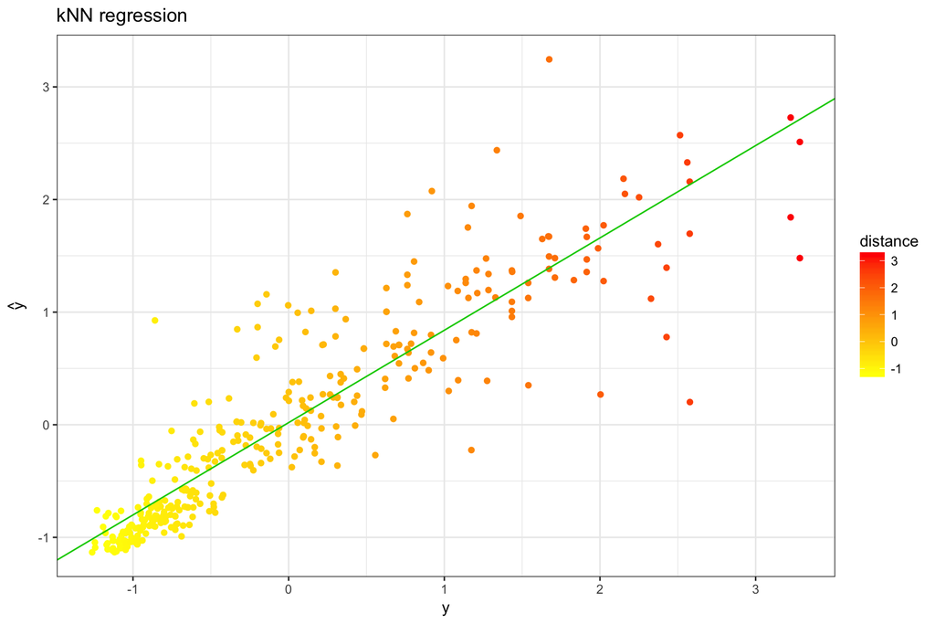

```r
gg + geom_abline(intercept=c[1], slope=c[2], col="green3")
```

Materials compiled from:  
[-Lantz, Brett. 2013. Machine Learning with R. Birmingham, UK: Packt Publishing, Ltd.](https://www.amazon.com/Machine-Learning-Second-Brett-Lantz/dp/1784393908)  
[-James G, Witten D, Hastie T, Tibshirani R. 2015. An Introduction to Statistical Learning - with applications in R, 6th ed. Springer: New York](http://www-bcf.usc.edu/~gareth/ISL/ISLR%20Sixth%20Printing.pdf)  
[-knnEval help page](https://artax.karlin.mff.cuni.cz/r-help/library/chemometrics/html/knnEval.html)